# 255 Assignment 3

Henry Gann - hgan927 - 501 429 763

# Question 2

## a)

```r
library(tidyverse)
generation = read_csv("generation.csv", col_names = TRUE)
plants = read_csv("plants.csv", col_names = TRUE)
generation$Fuel=as.factor(plants$Fuel[match(generation$Node,plants$Node)])
generation$Region=as.factor(plants$Region[match(generation$Node,plants$Node)])
generation$Emissions=plants$Emissions[match(generation$Node,plants$Node)]

show(generation)
```

```
## # A tibble: 25,852 x 53
##    Node  Date    TP1   TP2   TP3   TP4   TP5   TP6   TP7   TP8   TP9  TP10  TP11
##    <chr> <chr> <dbl> <dbl> <dbl> <dbl> <dbl> <dbl> <dbl> <dbl> <dbl> <dbl> <dbl>
##  1 ARA2~ 1/01~  6110  6140  5900  5950  6030  6110  5920  6050  6210  6200  6230
##  2 ARA2~ 2/01~  5670  5430  5400  5410  5290  5180  5470  5360  5400  5360  5340
##  3 ARA2~ 3/01~  5870  6090  5930  6000  6090  5960  6060  6100  6050  6130  6030
##  4 ARA2~ 4/01~  5810  5960  5980  5860  5780  5810  5750  5750  6050  5660  5620
##  5 ARA2~ 5/01~  5520  5670  5500  5670  5730  5760  5770  5700  5750  5620  5940
##  6 ARA2~ 6/01~  6270  6670  6370  6390  6920  7560  7590  7320  7060  7340  6970
##  7 ARA2~ 7/01~  5380  5440  5530  5460  5550  5620  5720  5740  5580  5690  5850
##  8 ARA2~ 8/01~  5750  5870  5930  5860  5970  6000  6010  6000  6030  6010  5870
##  9 ARA2~ 9/01~ 11120 11300 11260  9810 10350  8980  9390 10830 10770 10680 10830
## 10 ARA2~ 10/0~ 13110 13030 12480 12440 12470 12420 12450 12530 12500 12490 12500
## # ... with 25,842 more rows, and 40 more variables: TP12 <dbl>, TP13 <dbl>,
## #   TP14 <dbl>, TP15 <dbl>, TP16 <dbl>, TP17 <dbl>, TP18 <dbl>, TP19 <dbl>,
## #   TP20 <dbl>, TP21 <dbl>, TP22 <dbl>, TP23 <dbl>, TP24 <dbl>, TP25 <dbl>,
## #   TP26 <dbl>, TP27 <dbl>, TP28 <dbl>, TP29 <dbl>, TP30 <dbl>, TP31 <dbl>,
## #   TP32 <dbl>, TP33 <dbl>, TP34 <dbl>, TP35 <dbl>, TP36 <dbl>, TP37 <dbl>,
## #   TP38 <dbl>, TP39 <dbl>, TP40 <dbl>, TP41 <dbl>, TP42 <dbl>, TP43 <dbl>,
## #   TP44 <dbl>, TP45 <dbl>, TP46 <dbl>, TP47 <dbl>, TP48 <dbl>, Fuel <fct>,
## #   Region <fct>, Emissions <dbl>
```

## b)

```r
windgen = filter(generation, Fuel == 'Wind')
show(windgen)
```

```
## # A tibble: 3,285 x 53
##    Node  Date     TP1    TP2    TP3    TP4    TP5    TP6    TP7    TP8    TP9
##    <chr> <chr>  <dbl>  <dbl>  <dbl>  <dbl>  <dbl>  <dbl>  <dbl>  <dbl>  <dbl>
##  1 BPE0~ 1/01~ 4.26e3  3368.  3221.  3851.  2891.  2048.  1869.  1269.   870.
##  2 BPE0~ 2/01~ 0.         0      0      0      0      0      0      0      0
##  3 BPE0~ 3/01~ 0.         0      0      0      0      0      0      0      0
##  4 BPE0~ 4/01~ 0.         0      0      0      0      0      0      0      0
##  5 BPE0~ 5/01~ 1.39e4 13314. 14080. 13842. 13028. 13464. 14372. 14342. 14129.
##  6 BPE0~ 6/01~ 5.64e3 10095. 10762. 10165.  7858.  4811.  2510.   944.   563.
##  7 BPE0~ 7/01~ 3.67e3  4248.  3545.  3389.  3029.  2996.  4018.  3716.  3841.
##  8 BPE0~ 8/01~ 8.71e3  6946.  6480.  6638.  8010.  9491.  8334.  9735. 11755.
##  9 BPE0~ 9/01~ 8.57e0   590.  2062.  4062.  5151.  4299.  2146.  2572.  3554.
## 10 BPE0~ 10/0~ 1.87e3  1382.  1821.  1876.  2455.  3908.  4186.  5214.  5608.
## # ... with 3,275 more rows, and 42 more variables: TP10 <dbl>, TP11 <dbl>,
## #   TP12 <dbl>, TP13 <dbl>, TP14 <dbl>, TP15 <dbl>, TP16 <dbl>, TP17 <dbl>,
## #   TP18 <dbl>, TP19 <dbl>, TP20 <dbl>, TP21 <dbl>, TP22 <dbl>, TP23 <dbl>,
## #   TP24 <dbl>, TP25 <dbl>, TP26 <dbl>, TP27 <dbl>, TP28 <dbl>, TP29 <dbl>,
## #   TP30 <dbl>, TP31 <dbl>, TP32 <dbl>, TP33 <dbl>, TP34 <dbl>, TP35 <dbl>,
## #   TP36 <dbl>, TP37 <dbl>, TP38 <dbl>, TP39 <dbl>, TP40 <dbl>, TP41 <dbl>,
## #   TP42 <dbl>, TP43 <dbl>, TP44 <dbl>, TP45 <dbl>, TP46 <dbl>, TP47 <dbl>,
## #   TP48 <dbl>, Fuel <fct>, Region <fct>, Emissions <dbl>
```

## c)

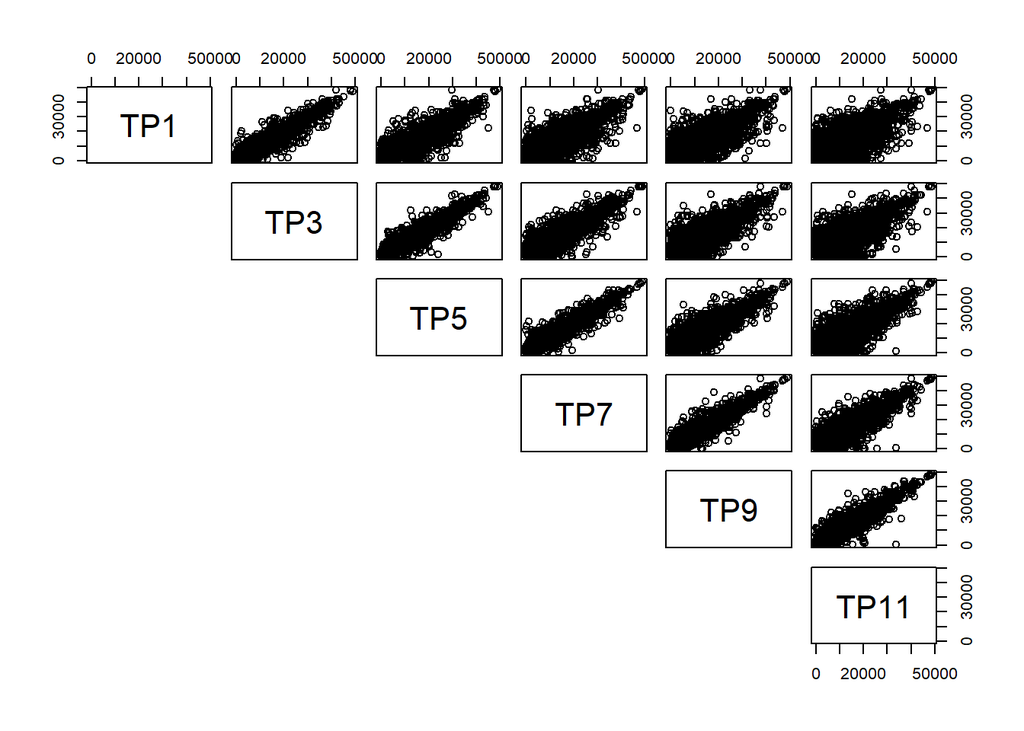

```r
pairs(windgen[c(3,5,7,9,11,13)], lower.panel =NULL, cex.labels = 2)
```

We can see that there is a positive linear relationship between the time periods that appears to approximate y = x. However, we do note that as the time between the time periods increases, so does the variance of the data from this approximate linear relationship.

## d)

```r
generation_gather = gather(generation,key =TP,value = kWh,starts_with("TP"))
show(generation_gather)
```

```
## # A tibble: 1,240,896 x 7
##    Node    Date       Fuel  Region Emissions TP      kWh
##    <chr>   <chr>      <fct> <fct>      <dbl> <chr> <dbl>
##  1 ARA2201 1/01/2018  Hydro USI            0 TP1    6110
##  2 ARA2201 2/01/2018  Hydro USI            0 TP1    5670
##  3 ARA2201 3/01/2018  Hydro USI            0 TP1    5870
##  4 ARA2201 4/01/2018  Hydro USI            0 TP1    5810
##  5 ARA2201 5/01/2018  Hydro USI            0 TP1    5520
##  6 ARA2201 6/01/2018  Hydro USI            0 TP1    6270
##  7 ARA2201 7/01/2018  Hydro USI            0 TP1    5380
##  8 ARA2201 8/01/2018  Hydro USI            0 TP1    5750
##  9 ARA2201 9/01/2018  Hydro USI            0 TP1   11120
## 10 ARA2201 10/01/2018 Hydro USI            0 TP1   13110
## # ... with 1,240,886 more rows
```

## e)

```r
generation_fuel= group_by(generation_gather, Fuel)
generation_summary = summarise(generation_fuel,sum(kWh,na.rm = TRUE))
show(generation_summary)
```

```
## # A tibble: 7 x 2
##   Fuel   `sum(kWh, na.rm = TRUE)`
##   <fct>                     <dbl>
## 1 Coal                1172218419
## 2 Diesel                 6442272
## 3 Gas                 5152578274.
## 4 Geo                 7186940949.
## 5 Hydro              25303822919.
## 6 Wind                1658599462.
## 7 Wood                 220056433
```

## f)

```r
generation_region = group_by(generation_fuel, Region)
generation_region$TP =  as.integer(gsub("TP", "", generation_gather$TP))
head(generation_region)
```

| Node | Date | Fuel | Region | Emissions | TP | kWh |
| --- | --- | --- | --- | --- | --- | --- |
| ARA2201 | 1/01/2018 | Hydro | USI | 0 | 1 | 6110 |
| ARA2201 | 2/01/2018 | Hydro | USI | 0 | 1 | 5670 |
| ARA2201 | 3/01/2018 | Hydro | USI | 0 | 1 | 5870 |
| ARA2201 | 4/01/2018 | Hydro | USI | 0 | 1 | 5810 |
| ARA2201 | 5/01/2018 | Hydro | USI | 0 | 1 | 5520 |
| ARA2201 | 6/01/2018 | Hydro | USI | 0 | 1 | 6270 |

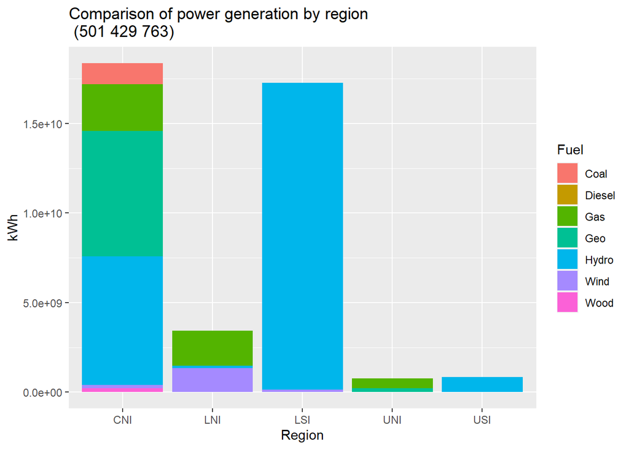

```r
g = ggplot(generation_region) + geom_col(aes( y = kWh, x = Region, fill = Fuel)) + labs(title = "Comparison of power generation by region \n (501 429 763)")
plot(g)
```

We can see that CNI and LSI produce significantly more energy than the other regions, and that LSI only uses wind and hydro energy, which has no emissions. We also note that Wood is not a major source of energy production in any region.

## g)

```r
library(lubridate)
generation_gather$TP =  as.integer(gsub("TP", "", generation_gather$TP))
generation_gather$Date = parse_date_time(generation_gather$Date, "dmy")
generation_gather$Month = as.factor(month(generation_gather$Date))
generation_line = group_by(generation_gather,Month,TP)
generation_line= summarise(generation_line,kWh = mean(kWh,na.rm=TRUE))
```

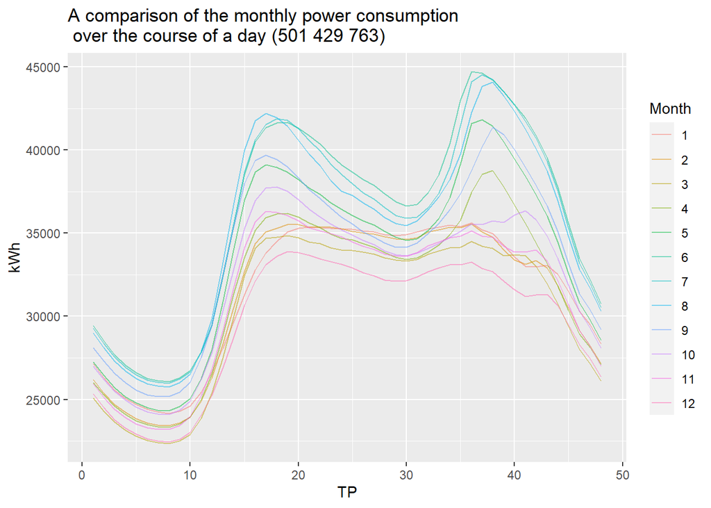

```r
g = ggplot(generation_line,aes(x=TP,y = kWh, color = Month)) + geom_line(alpha = 0.5) + labs(title = "A comparison of the monthly power consumption \n over the course of a day (501 429 763) ")
plot(g)
```

From the line graph above, we notice that in the middle months of the year, this is when energy production seems to be the highest. This is likely due to these being the winter months. There also is a major increase in energy production between about 5AM and 10AM (TP10 and TP20), which then steadily decreases at around 10AM. Then at about 3PM (TP30), it begins to increase rapidly again until about 7PM at which point, it begins to decline again.

## h)

```r
generation_hydro = filter(generation_gather, Fuel == "Hydro")
generation_hydro$Day = as.factor(day(generation_hydro$Date))
generation_hydro = group_by(generation_hydro,Month,Day)
generation_hydro = summarise(generation_hydro,kWh = sum(kWh,na.rm=TRUE))
```

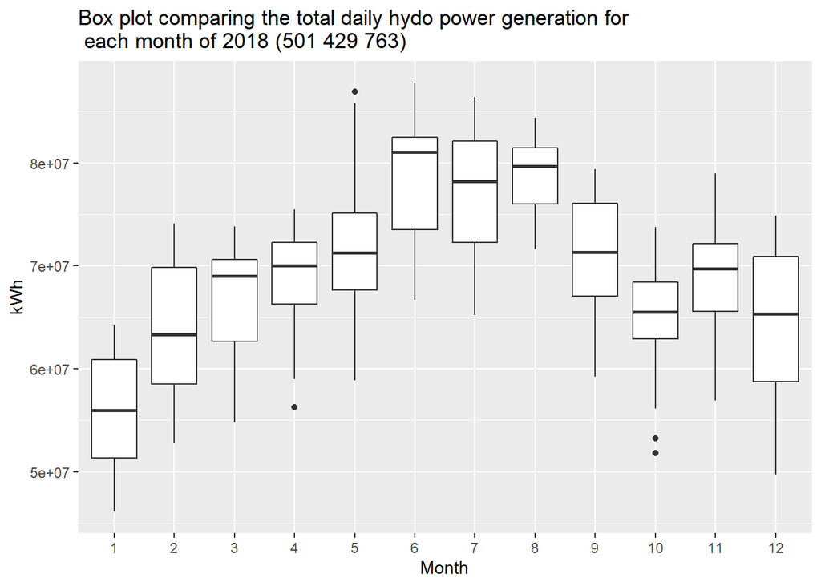

```r
g= ggplot(generation_hydro,aes(x=Month,y = kWh)) + geom_boxplot() + labs(title = "Box plot comparing the total daily hydo power generation for \n each month of 2018 (501 429 763)")
plot(g)
```

## i)

```r
generation_emissions = group_by(generation_gather, Region)
generation_emissions$Emissions = generation_emissions$Emissions * generation_emissions$kWh
generation_emissions = summarise(generation_emissions, Generation = sum(kWh,na.rm = TRUE), Emissions = sum(Emissions,na.rm=TRUE))
emissions = as_tibble(generation_emissions)
show(emissions)
```

```
## # A tibble: 5 x 3
##   Region   Generation   Emissions
##   <fct>         <dbl>       <dbl>
## 1 CNI    18370737453. 3028781004.
## 2 LNI     3439565158. 1225816944.
## 3 LSI    17275682503.          0
## 4 UNI      771279726.  417928349.
## 5 USI      843393889.          0
```

## j)

```r
library("leaflet")
regions = read_csv("regions.csv")
colorFact = colorFactor(c("red","green","blue","orange","black"), domain = c("UNI","CNI","LNI","USI","LSI"))
leaflet(regions)%>%addTiles()%>%addCircleMarkers(color = ~colorFact(Region),stroke = TRUE, radius = 10)
```

```
## Assuming "Lng" and "Lat" are longitude and latitude, respectively
```

[interactive chart not shown]

## k)

```r
regions$Emissions = emissions$Emissions[match(regions$Region,emissions$Region)]
regions$Generation = emissions$Generation[match(regions$Region,emissions$Region)]
regions$Ratio = regions$Emissions/regions$Generation

colourNum = colorNumeric("plasma", regions$Ratio)
leaflet(regions)%>%addTiles()%>%addCircleMarkers(color = ~colourNum(Ratio), radius = ~(regions$Generation/1e7)^0.5) %>% addLegend("bottomright",pal = colourNum,values=~regions$Ratio, title = "Carbon intensity (Kg CO2/kWh)")
```

```
## Assuming "Lng" and "Lat" are longitude and latitude, respectively
```

[interactive chart not shown]